# Problema 1 - Checkpoint 4 - Relatório Final

Davi Laerte

May 29, 2017

## Introdução aos dados

Nesse relatório, para a discplina de **Análise de Dados 1(UFCG)**, usarei os [dados](https://raw.githubusercontent.com/nazareno/imdb-series/master/data/series_from_imdb.csv) coletados do IMDB sobre pouco mais de 30 séries de TV e pretendo escolher três séries para responder as seguintes perguntas:

1. Episódios pilotos das séries mais populares, as séries com maior número de votos por episódio, são bem avaliados se comparados com os outros episódios da série ?
2. A série de tv Game Of Thrones possui alguns episódios escritos por George R. R. Martin o autor dos livros em que a série é baseada, os episódios escritos por George R. R. Martin são bem avaliados de acordo com o IMDB ?

Esses dados contém as seguintes informações sobre as séries: número de cada episódio das séries, temporada de cada episódio das séries, url com o link para o episódio indicado da série, nome do episódio, avaliação daquele episódio pelo IMDB, número de votos daquele episódio e a porcetagem de pessoas que votaram em cada nota(de 1 a 10) para aquele episódio.

```r
# carregando a biblioteca e importando os dados.

library(tidyverse)
dados_series <- read.csv("https://raw.githubusercontent.com/nazareno/imdb-series/master/data/series_from_imdb.csv", sep = ",")
```

## Respondendo a primeira pergunta

Para responder a primeira pergunta, utilizarei os dados sobre o número de votos de cada episódio, o número de episódios da série e suas respectivas avaliações, sendo assim pegarei as 5 séries mais votadas no meu conjunto de dados, para tanto primeiro preciso definir quais as séries mais votadas no conjunto de dados, usarei então a média do número de votos por episódio das séries como parâmetro para decidir quais a séries mais votadas, ordenando em ordem descrescente pela a média temos a seguinte tabela:

### Tabela de séries mais votadas em ordem descrescente

```r
# obtêm as séries mais votads em ordem descrescente
series_summarizadas <- dados_series %>% group_by(series_name) %>% summarise(numero_votos_media = mean(UserVotes)) %>% arrange(desc(numero_votos_media))

head(series_summarizadas, 31)
```

```
## # A tibble: 31 x 2
##         series_name numero_votos_media
##              <fctr>              <dbl>
##  1  Game of Thrones          22047.650
##  2         Sherlock          19415.400
##  3     Breaking Bad          12531.871
##  4     Black Mirror          12519.846
##  5 The Walking Dead           8276.667
##  6  Stranger Things           7753.125
##  7        Daredevil           5245.231
##  8         Mr Robot           4466.364
##  9            Flash           3568.768
## 10          The 100           3112.017
## # ... with 21 more rows
```

Tirarei os 5 primeiros lugares dessa tabela.

```r
# transforma os nomes da série em caracteres para poderem ser pesquisados
series_summarizadas$series_name <- as.character(series_summarizadas$series_name)

# pega os nomes das 5 primeiras séries mais populares
nomes_series_populares <- head(series_summarizadas, 5)$series_name

# filtra os dados das 5 séries mais populares
series_mais_populares <- dados_series %>% filter(series_name %in% nomes_series_populares)
```

### Gráfico de episódios por avaliação por série

Assim dando uma olhado nos dados através de um gráfico de episódios por avaliação, para cada série, temos:

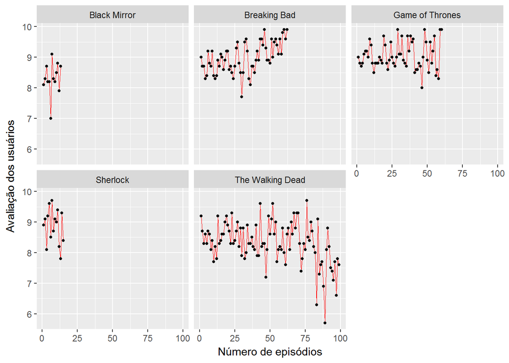

```r
# plota o de episódios por avaliação

ggplot(data = series_mais_populares, aes(x=series_ep, y=UserRating)) +
labs(colour = "Nome da série") +
labs(x = "Número de episódios") +
labs(y = "Avaliação dos usuários") +
geom_line(size = 0.3, color = "red") +
geom_point(size = 1) +
facet_wrap(~series_name)
```

Pode se perceber que existe uma certa têndencia de crescimento do gráfico a medida que o número de episódios vai se distanciando do primeiro episódio, apesar de ainda existir alguns episódios que estão abaixo da avaliação do primeiro episódio, as 4 primeiras séries apresetam um certo crescimento em relação a avaliação do primeiro episódio e a ultima série, The Walking Dead, tem um certo crescimento mas nos seus últimos episódios apresenta uma queda da avaliações em relação ao primeiro episódio.

Para concretizar o que vi no gráfico, decidi olhar para as medidas de valores centrais das séries(média e mediana), a questão é qual a diferença entre a média e mediana dos episódios(sem contar o primeiro episódio) das séries em relação ao primeiro episodio a diferença é significativa, ou esse episódios tendem a ficar perto da média.

```r
# pega os dados dos episódios das séries populares sem o episódio inicial de cada uma
series_mais_populares_sem_piloto <- series_mais_populares %>% filter(!series_ep %in% c(1))

# pega apenas os dados dos episódios pilotos das séries populares
series_mais_populares_pilotos <- series_mais_populares %>% filter(series_ep %in% c(1)) %>% arrange(series_name)

# constroi a tabela com a media e mediana do episódios(excluindo os episódios iniciais)
series_summarizadas_populares <- series_mais_populares_sem_piloto %>% group_by(series_name) %>% summarise(avaliacoes_media_sem_piloto = mean(UserRating), avaliacoes_mediana_sem_piloto = median(UserRating)) %>% arrange(series_name)

# adiciona na tabela as avaliações de cada episódio piloto das séries
series_summarizadas_populares$avaliacaoPiloto <- series_mais_populares_pilotos$UserRating
```

### Gráfico avalições dos episodios pilotos pela as avalições médias

Assim para melhor visualização plotarei um gráfico das avalições dos episodios pilotos pela as avalições médias dos outros episódios, valores que tocam a linha que corta a digonal do gráfico, são valores aonde a avaliação do episódio piloto está muito proxima da média de avaliações dois outros episódios, abaixo o gráfico:

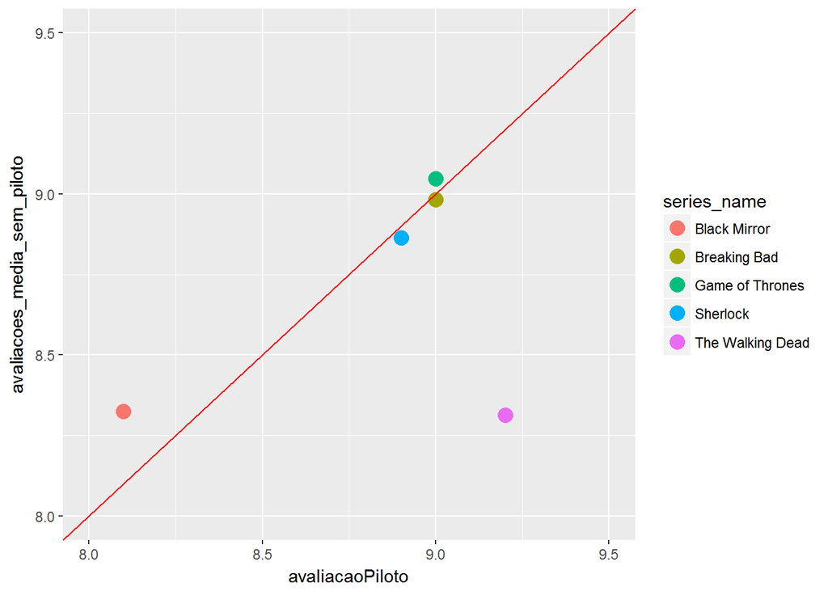

```r
ggplot(data = series_summarizadas_populares, aes(x=avaliacaoPiloto, y=avaliacoes_media_sem_piloto, color=series_name))+
geom_point(size = 4) +
geom_abline(size = 0.5, color = "red") +
xlim(8,9.5) +
ylim(8,9.5)
```

### Gráfico avalições dos episodios pilotos pela mediana das avaliaçoes

Também plotarei um gráfico da mediana das avaliações pela avaliação do primeiro episódio, onde os pontos que tocam a linha que corta o gráfico na diagonal, são valores onde a mediana das avaliações está muito perto da avaliação do primeiro episódio.

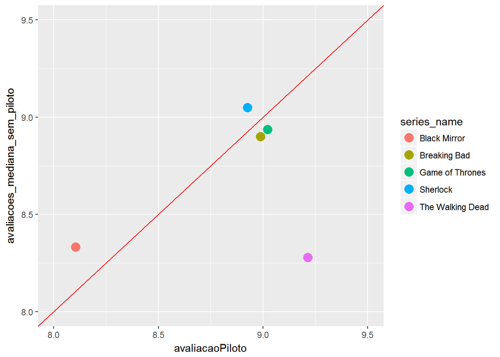

```r
ggplot(data = series_summarizadas_populares, aes(x=avaliacaoPiloto, y=avaliacoes_mediana_sem_piloto, color=series_name))+
geom_point(position = 'jitter', size = 4) +
geom_abline(size = 0.5, color = "red") +
xlim(8,9.5) +
ylim(8,9.5)
```

Pude notar nos dois gráficos que a maioria dos pontos ficava bem perto ou em cima da linha que dividia o gráfico onde a mesma representa os pontos onde os valores de avaliação do piloto e avaliação media são iguais, ou seja as avaliações dos episódios pilotos são bem próximos da media e mediana dos outros episódios.

### Conclusão da primeira pergunta

Depois de analisar os dados obtidos sobre os episódios das séries mais populares, as com maior número de votos, cheguei a conclusão que os episódios pilotos normalmente tendem a se aproximar das medidas centrais das avaliações dos episódios, assim respondendo a questão, com base nos dados estudados, os episódios pilotos das séries mais populares são avaliados como episódios medianos em relação aos outros.

## Respondendo a segunda pergunta

Para responder a segunda pergunta, pegarei os dados da séries Game of Thrones e com base nas informações vistas na [Wikipedia](https://pt.wikipedia.org/wiki/Game_of_Thrones) é no própio [IMDB](http://www.imdb.com/title/tt0944947/) sobre quais episódios foram escritos pelo autor da série(George R.R. Martin),assim filtrarei meus dados.

```r
# pega os dados da série Game of Thrones
series_escolhidas <- dados_series %>% filter(series_name %in% c("Game of Thrones"))

# número dos episódios que foram escritos pelo autor, tirados do sites citados acima
episodios_escritos_pelo_autor <- c(8, 19, 27, 32)

# dados dos episódios que foram escritos pelo autor
dados_episodios_escritos_pelo_autor <- series_escolhidas %>% filter(series_ep %in% episodios_escritos_pelo_autor)

# dados dos episódios que não foram escritos pelo autor
dados_episodios_nao_escritos_pelo_autor <- series_escolhidas %>% filter(!series_ep %in% episodios_escritos_pelo_autor)
```

### Gráfico avaliação por número de episódios com informações sobre os episódios escritos pelo autor

Agora plotarei um gráfico, para dar uma olhada nos dados, sobre avaliação por número de episódios, onde a linha tracejada azul representa as avaliações dos episódios escritos pelo autor e a linha verde tracejada representa os episódios escritos pelo autor, abaixo o gráfico:

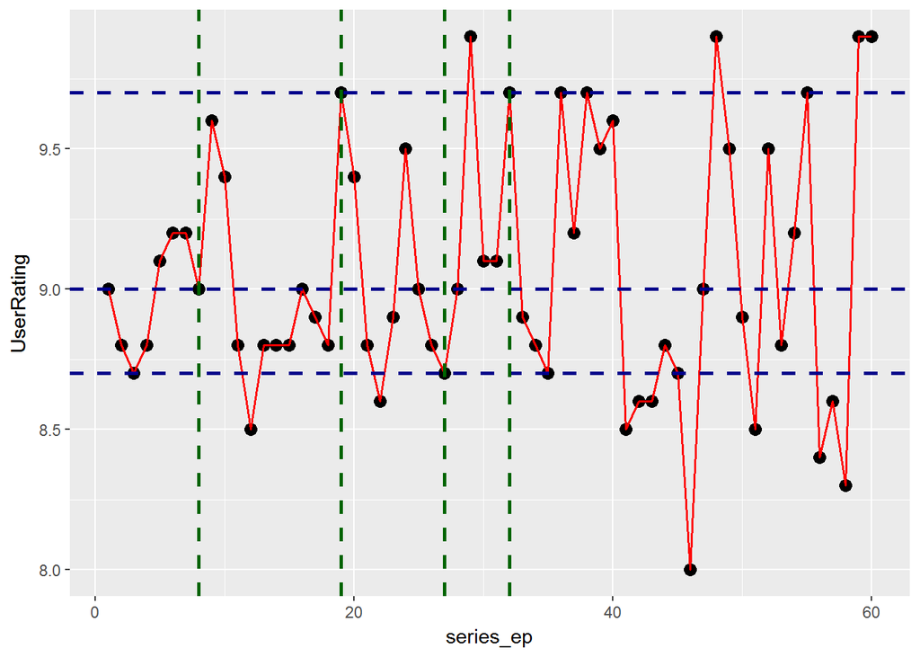

```r
ggplot(data = series_escolhidas, aes(x=series_ep, y=UserRating))+
geom_point(size = 3) +
geom_line(color="red", size = 0.7) +
geom_hline(yintercept = dados_episodios_escritos_pelo_autor$UserRating, color = "darkblue", size = 1, linetype = 2) +
geom_vline(xintercept = dados_episodios_escritos_pelo_autor$series_ep, color="darkgreen", size = 1 ,linetype = 2)
```

Olhando o gráfico percebi que dos 4 episódios escritos pelo autor, dois parecem estar com boa avaliação, ficando com os maiores pontos, um parece estar com avaliação media e o ultimo ponto parece estar um pouco abaixo da média.

### Gráfico avaliação por número de episódios dos episódios escritos pelo autor

Para melhor visualização farei um gráfico dos episódios escritos pelo autor(George R.R Martin) e suas respectivas avaliações, onde as linhas tracejadas fazem referência a valores do conjunto de dados dos episódios que o autor não escreveu, os valores representados pelas linha no gráfico são: linha preta - máximo, linha azul - média, linha verde - mediana e linha laranja - mínimo.

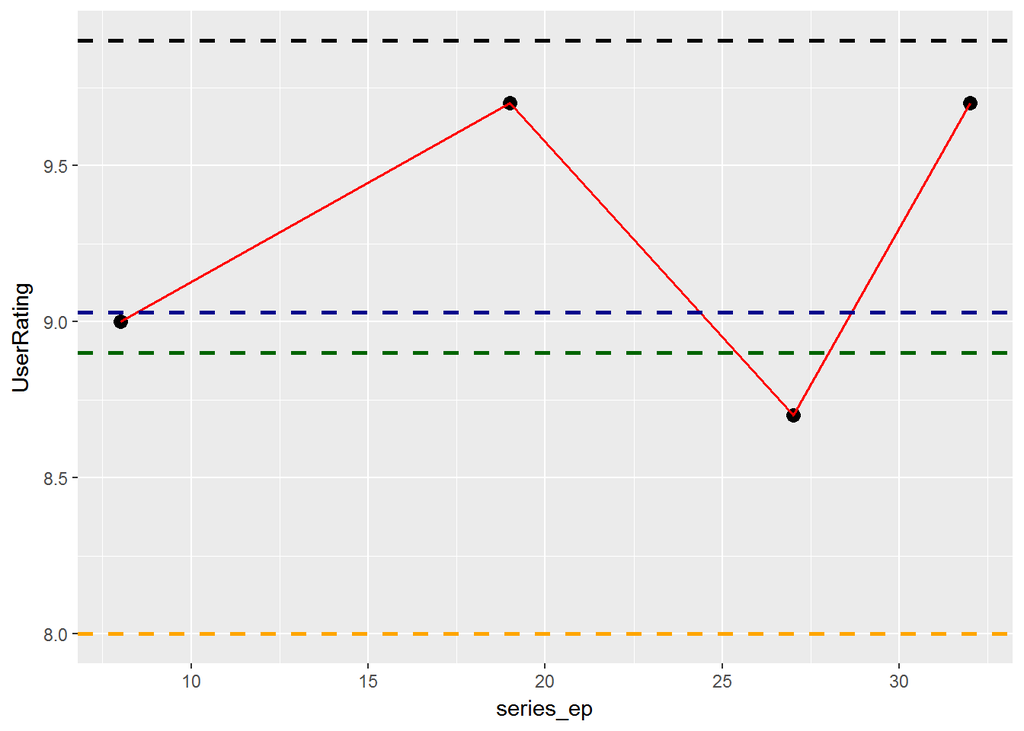

```r
ggplot(data = dados_episodios_escritos_pelo_autor, aes(x=series_ep, y=UserRating))+
geom_point(size = 3) +
geom_line(color="red", size = 0.7) +
geom_hline(yintercept = mean(mean(dados_episodios_nao_escritos_pelo_autor$UserRating)), color = "darkblue", size = 1, linetype = 2) +
geom_hline(yintercept = median(dados_episodios_nao_escritos_pelo_autor$UserRating), color = "darkgreen", size = 1, linetype = 2) +
geom_hline(yintercept = max(dados_episodios_nao_escritos_pelo_autor$UserRating), color = "black", size = 1, linetype = 2) +
geom_hline(yintercept = min(dados_episodios_nao_escritos_pelo_autor$UserRating), color = "orange", size = 1, linetype = 2)
```

Ao se analisar esse gráfico percebe-se que as avaliações dos episódios escritos pelo autor estão acima ou perto da média e mediana das avaliações, dos episódios que não foram escritos pelo autor, e dois deles estão bem próximos do maior valor de avaliação dos episódios que não foram escritos pelo autor.

Para tirar a dúvida final, irei averiguar qual média é maior, as das avaliações dos episódios escritos pelo autor ou as dos episódios que não foram escritos por eles, tendo em vista que a média dos episódios escritos pelo autor é:

```r
mean(dados_episodios_escritos_pelo_autor$UserRating)
```

```
## [1] 9.275
```

É a média de episódios que não foram escritos pelo autor é:

```r
mean(dados_episodios_nao_escritos_pelo_autor$UserRating)
```

```
## [1] 9.030357
```

Assim percebe-se que média de episódios escritos pelo autor é maior em relação a média dos episódios que não foram escritos por ele.

### Conclusão sengunda pergunta

Depois de analisar os dados cheguei a conclusão que os episódios escritos pelo autor de Game of Thrones(George R.R. Martin) são bem avaliados em relação aos outros episódios, pois o episódios escritos por eles estão ou perto da média dos outros episódios ou acima deles(perto dos mais bem avaliados), assim seus episódios são bem avaliados com relação aos demais.

## Perguntas que foram indetificadas na análise

Tendo analisado os dados acima e respondido as duas perguntas prospostas inicialmente, achei mais duas perguntas relevantes a partir dos resultados obtidos com as perguntas acima, são elas:

1. os episódios finais das séries menos populares, com menor número de votos, são mal avaliados se comparado com os outros episódios da série ?
2. os episódios escritos por George R. R. Martim(autor do livro de Game of Thrones) são bem votados segundo o IMDB ?

## Respodendo a primeira pergunta indetificada na análise

Para responder essa pergunta pegarei um caminho parecido que utilizei para reposnder a primeira pergunta respondida anteriormente, pegarei as 5 séries menos votadas no meu conjunto de dados, para tanto primeiro preciso definir quais as séries mneos votadas no conjunto de dados, usarei então a média do número de votos por episódio das séries como parâmetro para decidir quais a séries mneos votadas, ordenando em ordem crescente pela a média temos a seguinte tabela:

### Tabela da séries menos populares

```r
series_menos_populares <- dados_series %>% group_by(series_name) %>% summarise(numero_votos_media = mean(UserVotes)) %>% arrange(numero_votos_media)
head(series_menos_populares, 31)
```

```
## # A tibble: 31 x 2
##                    series_name numero_votos_media
##                         <fctr>              <dbl>
##  1                     Scandal           319.7170
##  2            Greyâs Anatomy           527.0822
##  3                The Simpsons           912.3841
##  4               Modern Family           943.6489
##  5                Orphan Black           950.6000
##  6            Once Upon a Time           991.6397
##  7               The Blacklist          1013.2921
##  8 How to Get Away with Murder          1080.4222
##  9                      Sense8          1669.5652
## 10      Agents of S.H.I.E.L.D.          1860.4091
## # ... with 21 more rows
```

Tirarei os 5 primeiros lugares dessa tabela.

```r
# transforma os nomes da série em caracteres para poderem ser pesquisados
series_menos_populares$series_name <- as.character(series_menos_populares$series_name)

# pega os nomes das 5 primeiras séries mais populares
nomes_series_menos_populares <- head(series_menos_populares, 5)$series_name
```

### Gráfico de episódios por avaliação da série **Scandall**

Dando uma olhado nos dados através de um gráfico de episódios por avaliação, para cada série, onde as linhas azul, verde, preto e laranja correspodem respctivamente a média, mediana, máximo e minimo das avaliações e a linha amarela corresponde a avaliação do ultimo episódio de cada série, assim temos a primeira série, **Scandall**:

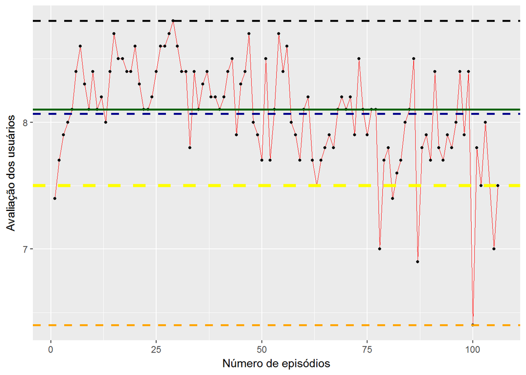

```r
# filtra os dados das primeira série menos popular
series_menos_populares_dados <- dados_series %>% filter(series_name %in% nomes_series_menos_populares[1])

# plota o gráfico
ggplot(data = series_menos_populares_dados, aes(x=series_ep, y=UserRating)) +
labs(colour = "Nome da série") +
labs(x = "Número de episódios") +
labs(y = "Avaliação dos usuários") +
geom_line(size = 0.3, color = "red") +
geom_point(size = 1) +
geom_hline(yintercept = mean(series_menos_populares_dados$UserRating), color="darkblue", linetype = 2, size = 1)+
geom_hline(yintercept = median(series_menos_populares_dados$UserRating), color="darkgreen", linetype = 1, size = 1) +
geom_hline(yintercept = max(series_menos_populares_dados$UserRating),  color="black", linetype = 2, , size = 1) +
geom_hline(yintercept = min(series_menos_populares_dados$UserRating),  color="orange", linetype = 2, , size = 1) +
geom_hline(yintercept = series_menos_populares_dados$UserRating[length(series_menos_populares_dados$UserRating)], color="yellow", linetype = 2, size = 1.5)
```

### Gráfico de episódios por avaliação da série **Greys Anatomy**

A segunda série, **Greys Anatomy**:

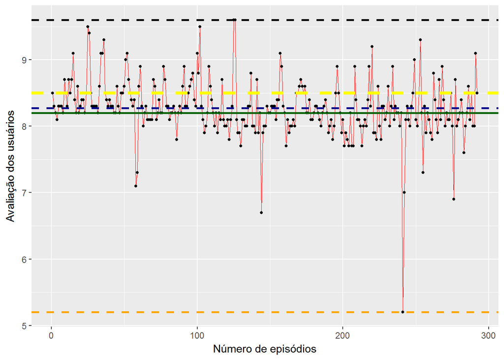

```r
# filtra os dados da segunda série menos popular
series_menos_populares_dados <- dados_series %>% filter(series_name %in% nomes_series_menos_populares[2])

# plota o gráfico
ggplot(data = series_menos_populares_dados, aes(x=series_ep, y=UserRating)) +
labs(colour = "Nome da série") +
labs(x = "Número de episódios") +
labs(y = "Avaliação dos usuários") +
geom_line(size = 0.3, color = "red") +
geom_point(size = 1) +
geom_hline(yintercept = mean(series_menos_populares_dados$UserRating), color="darkblue", linetype = 2, size = 1)+
geom_hline(yintercept = median(series_menos_populares_dados$UserRating), color="darkgreen", linetype = 1, size = 1) +
geom_hline(yintercept = max(series_menos_populares_dados$UserRating),  color="black", linetype = 2, , size = 1) +
geom_hline(yintercept = min(series_menos_populares_dados$UserRating),  color="orange", linetype = 2, , size = 1) +
geom_hline(yintercept = series_menos_populares_dados$UserRating[length(series_menos_populares_dados$UserRating)], color="yellow", linetype = 2, size = 1.5)
```

### Gráfico de episódios por avaliação da série **The simpsons**

A Terceira, **The Simpsons**:

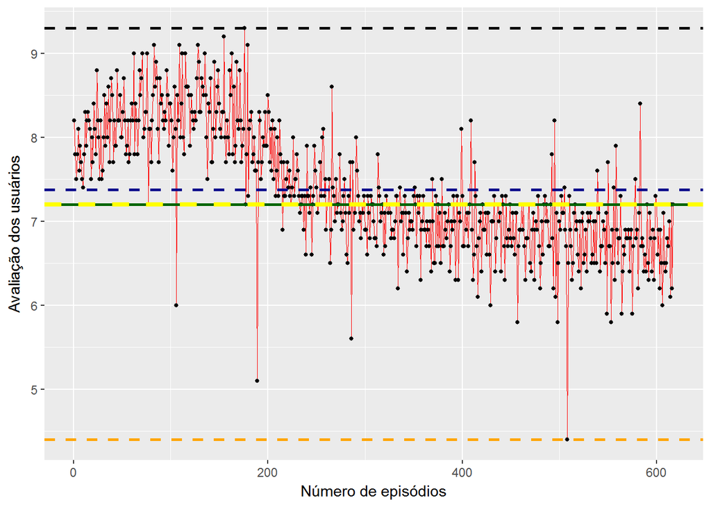

```r
# filtra os dados da segunda série menos popular
series_menos_populares_dados <- dados_series %>% filter(series_name %in% nomes_series_menos_populares[3])

# plota o gráfico
ggplot(data = series_menos_populares_dados, aes(x=series_ep, y=UserRating)) +
labs(colour = "Nome da série") +
labs(x = "Número de episódios") +
labs(y = "Avaliação dos usuários") +
geom_line(size = 0.3, color = "red") +
geom_point(size = 1) +
geom_hline(yintercept = mean(series_menos_populares_dados$UserRating), color="darkblue", linetype = 2, size = 1)+
geom_hline(yintercept = median(series_menos_populares_dados$UserRating), color="darkgreen", linetype = 1, size = 1) +
geom_hline(yintercept = max(series_menos_populares_dados$UserRating),  color="black", linetype = 2, , size = 1) +
geom_hline(yintercept = min(series_menos_populares_dados$UserRating),  color="orange", linetype = 2, , size = 1) +
geom_hline(yintercept = series_menos_populares_dados$UserRating[length(series_menos_populares_dados$UserRating)], color="yellow", linetype = 2, size = 1.5)
```

### Gráfico de episódios por avaliação da série **Modern Family**

A Quarta, **Modern Family**:

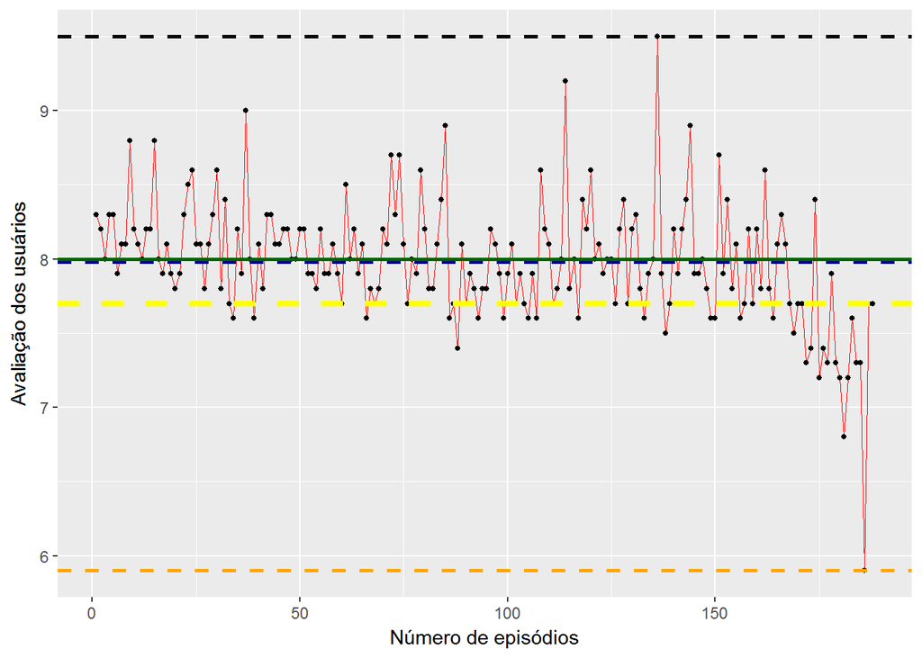

```r
# filtra os dados da segunda série menos popular
series_menos_populares_dados <- dados_series %>% filter(series_name %in% nomes_series_menos_populares[4])

# plota o gráfico
ggplot(data = series_menos_populares_dados, aes(x=series_ep, y=UserRating)) +
labs(colour = "Nome da série") +
labs(x = "Número de episódios") +
labs(y = "Avaliação dos usuários") +
geom_line(size = 0.3, color = "red") +
geom_point(size = 1) +
geom_hline(yintercept = mean(series_menos_populares_dados$UserRating), color="darkblue", linetype = 2, size = 1)+
geom_hline(yintercept = median(series_menos_populares_dados$UserRating), color="darkgreen", linetype = 1, size = 1) +
geom_hline(yintercept = max(series_menos_populares_dados$UserRating),  color="black", linetype = 2, , size = 1) +
geom_hline(yintercept = min(series_menos_populares_dados$UserRating),  color="orange", linetype = 2, , size = 1) +
geom_hline(yintercept = series_menos_populares_dados$UserRating[length(series_menos_populares_dados$UserRating)], color="yellow", linetype = 2, size = 1.5)
```

### Gráfico de episódios por avaliação da série **Orphan Black**

A Quinta, **Orphan Black**:

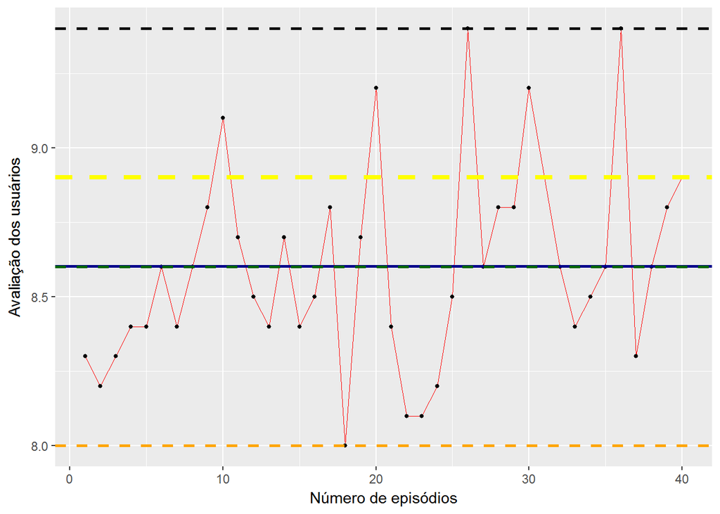

```r
# filtra os dados da segunda série menos popular
series_menos_populares_dados <- dados_series %>% filter(series_name %in% nomes_series_menos_populares[5])

# plota o gráfico
ggplot(data = series_menos_populares_dados, aes(x=series_ep, y=UserRating)) +
labs(colour = "Nome da série") +
labs(x = "Número de episódios") +
labs(y = "Avaliação dos usuários") +
geom_line(size = 0.3, color = "red") +
geom_point(size = 1) +
geom_hline(yintercept = mean(series_menos_populares_dados$UserRating), color="darkblue", linetype = 1, size = 1)+
geom_hline(yintercept = median(series_menos_populares_dados$UserRating), color="darkgreen", linetype = 2, size = 1) +
geom_hline(yintercept = max(series_menos_populares_dados$UserRating),  color="black", linetype = 2, , size = 1) +
geom_hline(yintercept = min(series_menos_populares_dados$UserRating),  color="orange", linetype = 2, , size = 1) +
geom_hline(yintercept = series_menos_populares_dados$UserRating[length(series_menos_populares_dados$UserRating)], color="yellow", linetype = 2, size = 1.5)
```

Dando uma olhada nos dados percebemos que não existe um padrão muito fixo alguns finais de séries estão bem avaliados em relação a média e mediana, outros estão mal avaliados e outros estão na média de avaliações.

### Conclusão primeira pergunta indetificada

Logo concluir a partir dos gráficos e dos dados analisados, que o fato da série ser menos popular não implica que seu último episódio é menor avaliado se comparado com os outros episódios da série, séries menos populares podem ter episódios finais bem ou mal avaliados independente da sua popularidade.

## Respondendo a segunda pergunta indetificada na análise

Para responder a segunda pergunta vou plotar um gráfico, para dar uma olhada nos dados, sobre número de votos por episódios, onde a linha tracejada azul representa o número de votos dos episódios escritos pelo autor e a linha verde tracejada representa os episódios escritos pelo autor, abaixo o gráfico:

### Gráfico sobre o número de votos por episódios

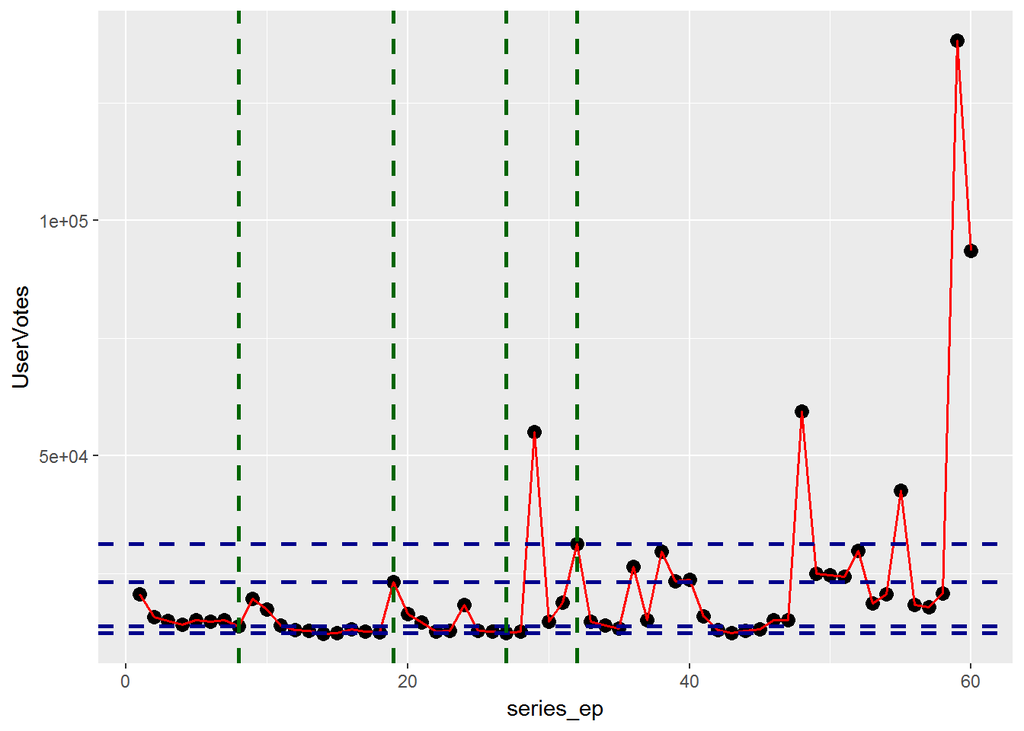

```r
ggplot(data = series_escolhidas, aes(x=series_ep, y=UserVotes))+
geom_point(size = 3) +
geom_line(color="red", size = 0.7) +
geom_hline(yintercept = dados_episodios_escritos_pelo_autor$UserVotes, color = "darkblue", size = 1, linetype = 2) +
geom_vline(xintercept = dados_episodios_escritos_pelo_autor$series_ep, color="darkgreen", size = 1 ,linetype = 2)
```

Analisando o gráfico acima se percebe que os episódios escritos pelo autor estão, aparentemente na média do número de votos, dois episódios estão um pouco mais acima dos outros e os outros dois estão onde a maioria dos episódios se encontra.

### Gráfico sobre o número de votos por episódios com episódios escritos pelo autor

Para melhor visualização farei um gráfico dos episódios escritos pelo autor(George R.R Martin) e suas respectivos número de votos, onde as linhas tracejadas fazem referência a valores do conjunto de dados dos episódios que o autor não escreveu, os valores representados pelas linha no gráfico são: linha preta - máximo, linha azul - média, linha verde - mediana e linha laranja - mínimo.

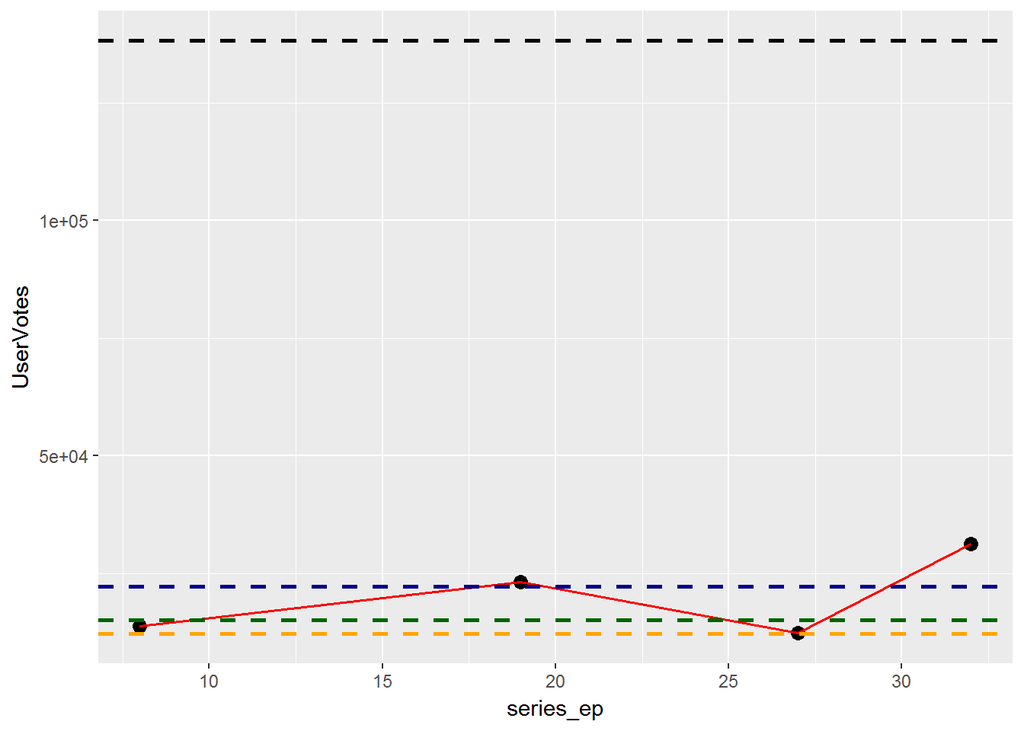

```r
ggplot(data = dados_episodios_escritos_pelo_autor, aes(x=series_ep, y=UserVotes))+
geom_point(size = 3) +
geom_line(color="red", size = 0.7) +
geom_hline(yintercept = mean(mean(dados_episodios_nao_escritos_pelo_autor$UserVotes)), color = "darkblue", size = 1, linetype = 2) +
geom_hline(yintercept = median(dados_episodios_nao_escritos_pelo_autor$UserVotes), color = "darkgreen", size = 1, linetype = 2) +
geom_hline(yintercept = max(dados_episodios_nao_escritos_pelo_autor$UserVotes), color = "black", size = 1, linetype = 2) +
geom_hline(yintercept = min(dados_episodios_nao_escritos_pelo_autor$UserVotes), color = "orange", size = 1, linetype = 2)
```

Olhando gráfico acima, vemos que os episódios escritos pelo autor estão na faixa média de número de votos da série, sendo apenas um episódio um pouco maior que a média.

### Conclusão da segunda pergunta indetificada

Observando os dados e os gráficos, cheguei a conclusão que os episódios, escritos pelo autor de Game of Thrones(George R.R. Martim) , estão na média de votos que série costuma ter por episódio.